# US HPAI Cases Dashboard

**Collection Frequency**

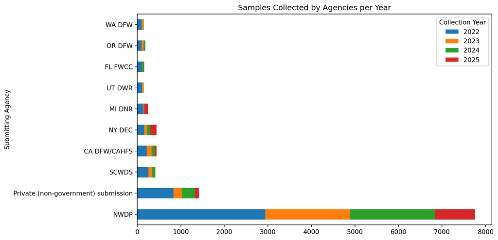

- 100+ agencies total, top 10 for brevity
- NWDP collects most samples by far each year (> 50% all)

**Seasonal Habits**

| Submitting Agency | Collection Year Season | 2022 | 2023 | 2024 | 2025 | Total Samples | % of Agency Samples | % of All Samples |
| --- | --- | --- | --- | --- | --- | --- | --- | --- |
| NWDP | Winter | 785.0 | 511.0 | 1429.0 | 637.0 | 3362.0 | 43.358 | 23.529 |
|  | Fall | 1449.0 | 1162.0 | 335.0 | 87.0 | 3033.0 | 39.115 | 21.226 |
|  | Spring | 610.0 | 43.0 | 75.0 | 143.0 | 871.0 | 11.233 | 6.096 |
| Private (non-government) submission | Spring | 350.0 | 41.0 | 101.0 | 11.0 | 503.0 | 35.472 | 3.520 |
| NWDP | Summer | 95.0 | 233.0 | 111.0 | 49.0 | 488.0 | 6.294 | 3.415 |
| Private (non-government) submission | Fall | 236.0 | 58.0 | 35.0 | 3.0 | 332.0 | 23.413 | 2.323 |
|  | Summer | 101.0 | 7.0 | 127.0 | 65.0 | 300.0 | 21.157 | 2.100 |
| Tufts University | Summer | 64.0 | 0.0 | 18.0 | 209.0 | 291.0 | 85.088 | 2.037 |
| Private (non-government) submission | Winter | 146.0 | 85.0 | 40.0 | 12.0 | 283.0 | 19.958 | 1.981 |
| CA DFW/CAHFS | Winter | 94.0 | 58.0 | 33.0 | 0.0 | 185.0 | 41.761 | 1.295 |
| NY DEC | Summer | 18.0 | 5.0 | 14.0 | 144.0 | 181.0 | 40.492 | 1.267 |
| PA Game Commission | Summer | 21.0 | 0.0 | 2.0 | 114.0 | 137.0 | 58.298 | 0.959 |
| SCWDS | Winter | 43.0 | 68.0 | 24.0 | 0.0 | 135.0 | 32.530 | 0.945 |
|  | Fall | 124.0 | 4.0 | 0.0 | 0.0 | 128.0 | 30.843 | 0.896 |
| MI DNR | Summer | 45.0 | 0.0 | 2.0 | 71.0 | 118.0 | 47.967 | 0.826 |

- NWDP Collects most samples in Winter and Fall, least in Summer
- May be seasonal bias since NWDP is largest contributor but samples significantly less during Spring and Summer

**Regional Habits**

| Submitting Agency | Collection Year Region | 2022 | 2023 | 2024 | 2025 | Total Samples | % of Agency Samples | % of All Samples |
| --- | --- | --- | --- | --- | --- | --- | --- | --- |
| NWDP | Midwest | 1074.0 | 731.0 | 364.0 | 205.0 | 2374.0 | 30.616 | 16.614 |
|  | South | 842.0 | 512.0 | 708.0 | 155.0 | 2217.0 | 28.592 | 15.515 |
|  | West | 626.0 | 600.0 | 678.0 | 115.0 | 2019.0 | 26.038 | 14.130 |
|  | Northeast | 397.0 | 106.0 | 200.0 | 441.0 | 1144.0 | 14.754 | 8.006 |
| NY DEC | Northeast | 159.0 | 66.0 | 76.0 | 145.0 | 446.0 | 99.776 | 3.121 |
| CA DFW/CAHFS | West | 218.0 | 113.0 | 72.0 | 40.0 | 443.0 | 100.000 | 3.100 |
| Private (non-government) submission | Midwest | 333.0 | 27.0 | 48.0 | 24.0 | 432.0 | 30.465 | 3.023 |
|  | South | 271.0 | 34.0 | 81.0 | 23.0 | 409.0 | 28.843 | 2.862 |
| Tufts University | Northeast | 78.0 | 14.0 | 40.0 | 207.0 | 339.0 | 99.123 | 2.372 |
| Private (non-government) submission | West | 152.0 | 92.0 | 51.0 | 14.0 | 309.0 | 21.791 | 2.163 |
|  | Northeast | 77.0 | 38.0 | 123.0 | 30.0 | 268.0 | 18.900 | 1.876 |
| MI DNR | Midwest | 145.0 | 14.0 | 6.0 | 81.0 | 246.0 | 100.000 | 1.722 |
| SCWDS | South | 124.0 | 53.0 | 63.0 | 3.0 | 243.0 | 58.554 | 1.701 |
| PA Game Commission | Northeast | 74.0 | 26.0 | 13.0 | 122.0 | 235.0 | 100.000 | 1.645 |
| OR DFW | West | 101.0 | 50.0 | 36.0 | 2.0 | 189.0 | 100.000 | 1.323 |

- NWDP collects most of its samples in Midwest, least in Northeast
- May be regional bias since NWDP is largest contributor but samples significantly less from Northeast

**Cases by Region**

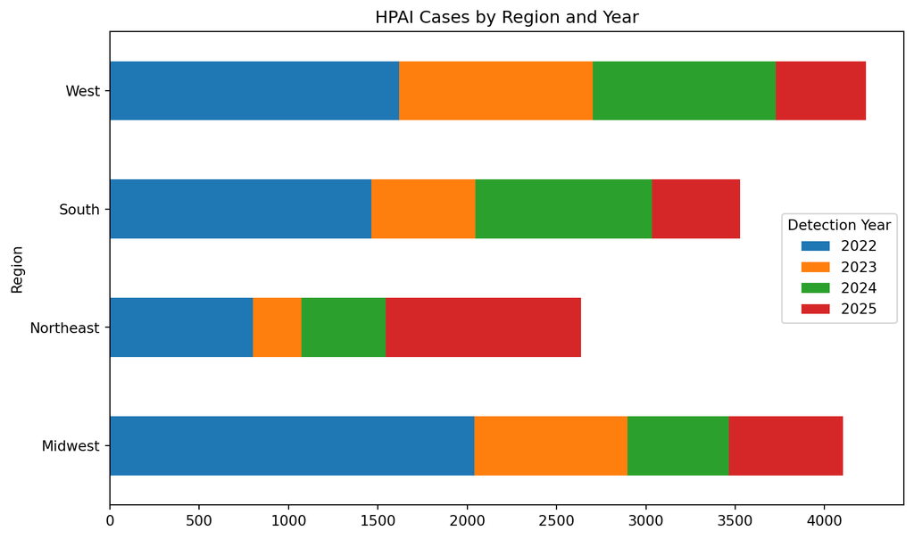

- West (29.2% all) and Midwest (28.3% all) have most cases, Northeast (18.2% all) has least
- NWDP is most active in Midwest, South, and West - may help explain higher case numbers
- South has noticably less cases than Midwest and West despite heavy NWDP activity - may indicate lack of sampling in region by other agencies

**Cases by Region and Season**

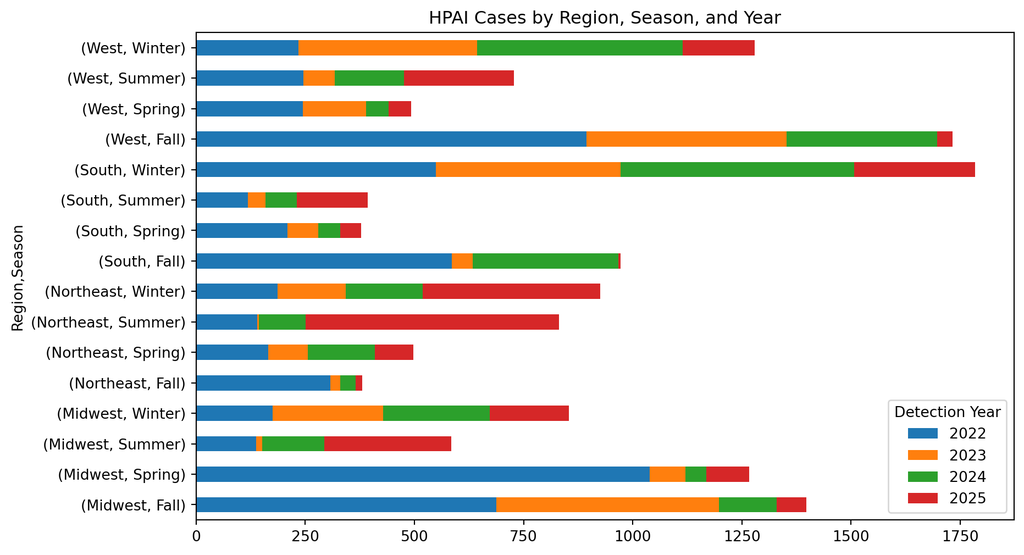

- South-Winter has most cases (12.3% all), Northeast-Fall has least (2.6% all)
- West has most cases in Fall and Winter
- Midwest has most cases in Fall and Spring
- Recall: NWDP most active in Midwest region and during Fall/Winter seasons in general

**Cases over Time**

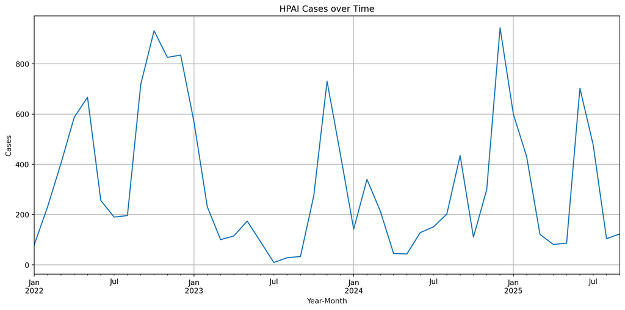

- Latest detection date: 09/19/2025
- We want to forecast out to Sep. 1, 2026 (about 1 year)

**Model**

- Seasonal Autoregressive Integrated Moving Average (SARIMA)
- Seasonal (S) - focuses on relationship between current value and past value at prior seasonal period (e.g. 12 months ago)
- Autoregressive (AR) - focuses on how past (lag) values affect current value
- Integrated (I) - calculates difference between current and prior values to data maintain stationarity (constant mean/variance over time)
- Moving Average (MA) - focuses on how past unexpected shocks (errors) affect current value

**Forecast**

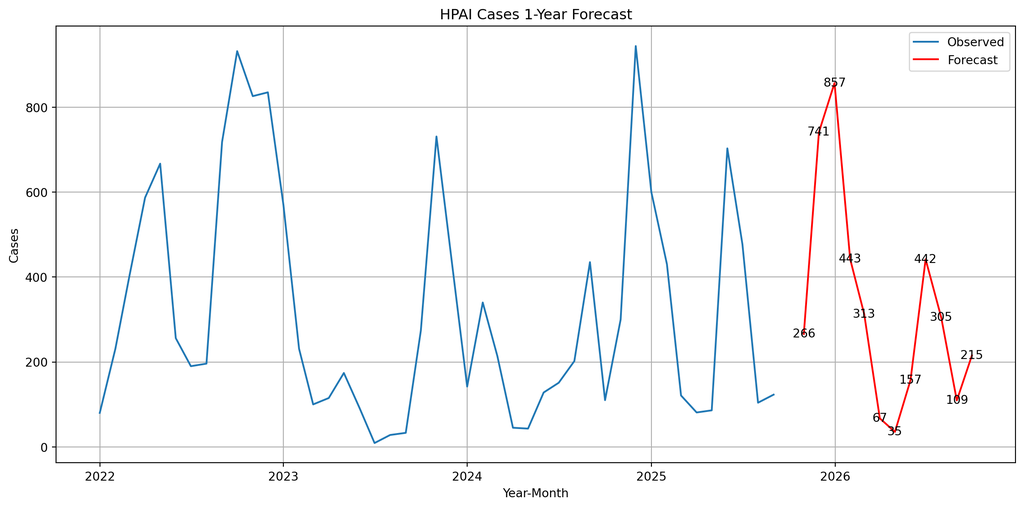

- Gap is due to incomplete data for Sep. 2025